# Project Python Foundations: FoodHub Data Analysis

**Marks: 60**

### Context

The number of restaurants in New York is increasing day by day. Lots of students and busy professionals rely on those restaurants due to their hectic lifestyles. Online food delivery service is a great option for them. It provides them with good food from their favorite restaurants. A food aggregator company FoodHub offers access to multiple restaurants through a single smartphone app.

The app allows the restaurants to receive a direct online order from a customer. The app assigns a delivery person from the company to pick up the order after it is confirmed by the restaurant. The delivery person then uses the map to reach the restaurant and waits for the food package. Once the food package is handed over to the delivery person, he/she confirms the pick-up in the app and travels to the customer's location to deliver the food. The delivery person confirms the drop-off in the app after delivering the food package to the customer. The customer can rate the order in the app. The food aggregator earns money by collecting a fixed margin of the delivery order from the restaurants.

### Objective

The food aggregator company has stored the data of the different orders made by the registered customers in their online portal. They want to analyze the data to get a fair idea about the demand of different restaurants which will help them in enhancing their customer experience. Suppose you are hired as a Data Scientist in this company and the Data Science team has shared some of the key questions that need to be answered. Perform the data analysis to find answers to these questions that will help the company to improve the business.

### Data Description

The data contains the different data related to a food order. The detailed data dictionary is given below.

### Data Dictionary

- order_id: Unique ID of the order
- customer_id: ID of the customer who ordered the food
- restaurant_name: Name of the restaurant
- cuisine_type: Cuisine ordered by the customer
- cost: Cost of the order
- day_of_the_week: Indicates whether the order is placed on a weekday or weekend (The weekday is from Monday to Friday and the weekend is Saturday and Sunday)
- rating: Rating given by the customer out of 5
- food_preparation_time: Time (in minutes) taken by the restaurant to prepare the food. This is calculated by taking the difference between the timestamps of the restaurant's order confirmation and the delivery person's pick-up confirmation.
- delivery_time: Time (in minutes) taken by the delivery person to deliver the food package. This is calculated by taking the difference between the timestamps of the delivery person's pick-up confirmation and drop-off information

### Let us start by importing the required libraries

```python
# import libraries for data manipulation
import numpy as np
import pandas as pd

# import libraries for data visualization
import matplotlib.pyplot as plt
import seaborn as sns
import warnings
warnings.filterwarnings("ignore")
```

### Understanding the structure of the data

```python
# Mounting google drive in Goggle colab
from google.colab import drive
drive.mount('/content/drive')
```

```python
# read the data
df = pd.read_csv('/content/drive/My Drive/foodhub_order.csv')
# returns the first 5 rows
df.head()
```

|  | order_id | customer_id | restaurant_name | cuisine_type | cost_of_the_order | day_of_the_week | rating | food_preparation_time | delivery_time |
| --- | --- | --- | --- | --- | --- | --- | --- | --- | --- |
| 0 | 1477147 | 337525 | Hangawi | Korean | 30.75 | Weekend | Not given | 25 | 20 |
| 1 | 1477685 | 358141 | Blue Ribbon Sushi Izakaya | Japanese | 12.08 | Weekend | Not given | 25 | 23 |
| 2 | 1477070 | 66393 | Cafe Habana | Mexican | 12.23 | Weekday | 5 | 23 | 28 |
| 3 | 1477334 | 106968 | Blue Ribbon Fried Chicken | American | 29.20 | Weekend | 3 | 25 | 15 |
| 4 | 1478249 | 76942 | Dirty Bird to Go | American | 11.59 | Weekday | 4 | 25 | 24 |

#### Observations:

The DataFrame has 9 columns as mentioned in the Data Dictionary. Data in each row corresponds to the order placed by a customer.

### **Question 1:** How many rows and columns are present in the data? [0.5 mark]

```python
#checking shape of the dataframe to find out the number of rows and columns using shape command
print("There are", df.shape[0], 'rows and', df.shape[1], "columns.")
```

```
There are 1898 rows and 9 columns.
```

#### Observations:The dataset contains 1898 rows and 9 columns.

### **Question 2:** What are the datatypes of the different columns in the dataset? (The info() function can be used) [0.5 mark]

```python
# Use info() to print a concise summary of the DataFrame
df.info()
```

```
<class 'pandas.core.frame.DataFrame'>
RangeIndex: 1898 entries, 0 to 1897
Data columns (total 9 columns):
 #   Column                 Non-Null Count  Dtype
---  ------                 --------------  -----
 0   order_id               1898 non-null   int64
 1   customer_id            1898 non-null   int64
 2   restaurant_name        1898 non-null   object
 3   cuisine_type           1898 non-null   object
 4   cost_of_the_order      1898 non-null   float64
 5   day_of_the_week        1898 non-null   object
 6   rating                 1898 non-null   object
 7   food_preparation_time  1898 non-null   int64
 8   delivery_time          1898 non-null   int64
dtypes: float64(1), int64(4), object(4)
memory usage: 133.6+ KB
```

#### Observations:

- There are 5 numerical columns (one(1) float64 datatype and four(4) integer datatype,) and 4 object type columns in the dataset.
- rating is read as object type column but it should be a numerical column.

```python
# let's see why rating column has object data type
df['rating'].unique()
```

```
array(['Not given', '5', '3', '4'], dtype=object)
```

```python
# checking the count of different data types in rating column
df['rating'].apply(type).value_counts()
```

```
<class 'str'>    1898
Name: rating, dtype: int64
```

```python
# replacing values with nan
df['rating'] = df['rating'].replace(['Not given'],np.nan)
```

```python
# changing the data type to integer
df['rating'] = df['rating'].astype(float)
```

```python
# let's check the data type of columns again
df.info()
```

```
<class 'pandas.core.frame.DataFrame'>
RangeIndex: 1898 entries, 0 to 1897
Data columns (total 9 columns):
 #   Column                 Non-Null Count  Dtype
---  ------                 --------------  -----
 0   order_id               1898 non-null   int64
 1   customer_id            1898 non-null   int64
 2   restaurant_name        1898 non-null   object
 3   cuisine_type           1898 non-null   object
 4   cost_of_the_order      1898 non-null   float64
 5   day_of_the_week        1898 non-null   object
 6   rating                 1162 non-null   float64
 7   food_preparation_time  1898 non-null   int64
 8   delivery_time          1898 non-null   int64
dtypes: float64(2), int64(4), object(3)
memory usage: 133.6+ KB
```

We see that the data type of rating columns have been fixed. There are 6 numerical columns, and 3 object type columns in the data. We observe that the rating columns have less entries than that other columns (less than 1898 rows) which indicates the presence of missing values in the data.

### **Question 3:** Are there any missing values in the data? If yes, treat them using an appropriate method. [1 mark]

```python
### Checking for missing values in the data by summing the whole null vallues in each column.
df.isnull().sum()
```

```
order_id                   0
customer_id                0
restaurant_name            0
cuisine_type               0
cost_of_the_order          0
day_of_the_week            0
rating                   736
food_preparation_time      0
delivery_time              0
dtype: int64
```

#### Observations:

There is a missing value in one(1) of the columns of the dataframe which is the rating. This means that some data values are not stored for the rating variable in some observations.

### **Question 4:** Check the statistical summary of the data. What is the minimum, average, and maximum time it takes for food to be prepared once an order is placed? [2 marks]

```python
# checking the statistical summary of the data using describe command and transposing.
df.describe().T
```

|  | count | mean | std | min | 25% | 50% | 75% | max |
| --- | --- | --- | --- | --- | --- | --- | --- | --- |
| order_id | 1898.0 | 1.477496e+06 | 548.049724 | 1476547.00 | 1477021.25 | 1477495.50 | 1.477970e+06 | 1478444.00 |
| customer_id | 1898.0 | 1.711685e+05 | 113698.139743 | 1311.00 | 77787.75 | 128600.00 | 2.705250e+05 | 405334.00 |
| cost_of_the_order | 1898.0 | 1.649885e+01 | 7.483812 | 4.47 | 12.08 | 14.14 | 2.229750e+01 | 35.41 |
| rating | 1162.0 | 4.344234e+00 | 0.741478 | 3.00 | 4.00 | 5.00 | 5.000000e+00 | 5.00 |
| food_preparation_time | 1898.0 | 2.737197e+01 | 4.632481 | 20.00 | 23.00 | 27.00 | 3.100000e+01 | 35.00 |
| delivery_time | 1898.0 | 2.416175e+01 | 4.972637 | 15.00 | 20.00 | 25.00 | 2.800000e+01 | 33.00 |

#### Observations:The minimum time it takes to prepare a food for an order is 20mins, the overall average time it takes to prepare a food is 27mins and the maximum time it takes to prepare a food for an order is 35mins.

### **Question 5:** How many orders are not rated? [1 mark]

```python
# Finding out he unique values in the rating series
df['rating'].unique()
#This list out all the unique values of the rating variable or series in an array.
#'Not given' indicates no rating.
#Therefore we go ahead to check the number of times 'Not given' appears using value counts method.
```

```
array([nan,  5.,  3.,  4.])
```

```python
#counting the number of orders that were not rated, this is gotten by counting the number of missing or null values.
df['rating'].isnull().sum()
```

```
736
```

#### Observations:The above shows that 736 orders were not rated

### Exploratory Data Analysis (EDA)

### **Question 6:** Explore all the variables and provide observations on their distributions. (Generally, histograms, boxplots, countplots, etc. are used for univariate exploration.) [9 marks]

### Observations on Numerical columns by checking the distribution for numerical columns.

**Observations on Cost of Order**

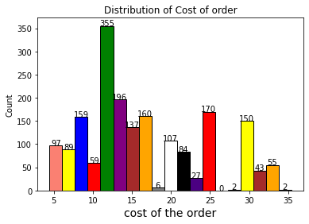

```python
ax = sns.histplot(df['cost_of_the_order'], color='#9d94ba', kde=False)
ax.set(title='Distribution of Cost of order')
ax.set_xlabel("cost of the order", fontsize=14)
# label each bar in histogram
for p in ax.patches:
 height = p.get_height() # get the height of each bar
 # adding text to each bar
 ax.text(x = p.get_x()+(p.get_width()/2), # x-coordinate position of data label, padded to be in the middle of the bar
 y = height+0.2, # y-coordinate position of data label, padded 0.2 above bar
 s = '{:.0f}'.format(height), # data label, formatted to ignore decimals
 ha = 'center') # sets horizontal alignment (ha) to center
 ax.patches[0].set_facecolor('salmon')
 ax.patches[1].set_facecolor('yellow')
 ax.patches[2].set_facecolor('blue')
 ax.patches[3].set_facecolor('red')
 ax.patches[4].set_facecolor('green')
 ax.patches[5].set_facecolor('purple')
 ax.patches[6].set_facecolor('brown')
 ax.patches[7].set_facecolor('orange')
 ax.patches[8].set_facecolor('gray')
 ax.patches[9].set_facecolor('white')
 ax.patches[10].set_facecolor('black')
 ax.patches[11].set_facecolor('indigo')
 ax.patches[12].set_facecolor('red')
 ax.patches[13].set_facecolor('green')
 ax.patches[14].set_facecolor('blue')
 ax.patches[15].set_facecolor('yellow')
 ax.patches[16].set_facecolor('brown')
 ax.patches[17].set_facecolor('orange')
 ax.patches[18].set_facecolor('black')
```

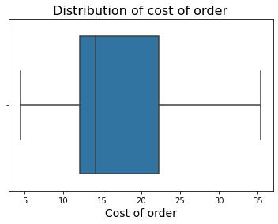

```python
bxp=sns.boxplot(data=df,x='cost_of_the_order')
bxp.set_xlabel("Cost of order", fontsize=14)
bxp.axes.set_title("Distribution of cost of order", fontsize=16)
plt.show()
```

**Observations on food preparation time**

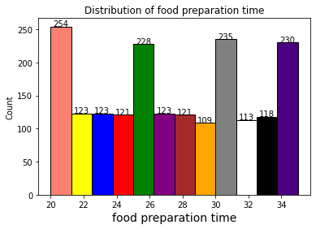

```python
ax = sns.histplot(df['food_preparation_time'], color='#9d94ba', kde=False)
ax.set(title='Distribution of food preparation time')
ax.set_xlabel("food preparation time", fontsize=14)
# label each bar in histogram
for p in ax.patches:
 height = p.get_height() # get the height of each bar
 # adding text to each bar
 ax.text(x = p.get_x()+(p.get_width()/2), # x-coordinate position of data label, padded to be in the middle of the bar
 y = height+0.2, # y-coordinate position of data label, padded 0.2 above bar
 s = '{:.0f}'.format(height), # data label, formatted to ignore decimals
 ha = 'center') # sets horizontal alignment (ha) to center
 ax.patches[0].set_facecolor('salmon')

 ax.patches[1].set_facecolor('yellow')
 ax.patches[2].set_facecolor('blue')
 ax.patches[3].set_facecolor('red')
 ax.patches[4].set_facecolor('green')
 ax.patches[5].set_facecolor('purple')
 ax.patches[6].set_facecolor('brown')
 ax.patches[7].set_facecolor('orange')
 ax.patches[8].set_facecolor('gray')
 ax.patches[9].set_facecolor('white')
 ax.patches[10].set_facecolor('black')
 ax.patches[11].set_facecolor('indigo')
```

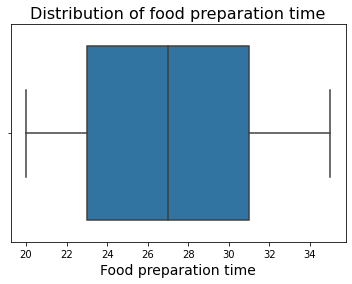

```python
bxp=sns.boxplot(data=df,x='food_preparation_time')
bxp.set_xlabel("Food preparation time", fontsize=14)
bxp.axes.set_title("Distribution of food preparation time", fontsize=16)
plt.show()
```

- The minimum time it takes for the preparation of an order once confirmed in most New York online restaurants is 20 minutes.
- There are no outliers in the column
- The maximum time it will take an order to be prepared once confirmed in the food aggregator app is around 35 minutes
- The data is not skewed
- 75% of the times it took to prepare food in the restaurants are below 31 minutes

**Observations on delivery time**

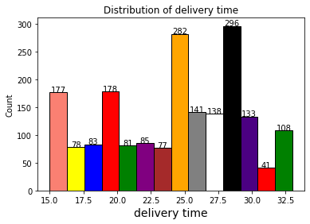

```python
ax = sns.histplot(df['delivery_time'], color='#9d94ba', kde=False)
ax.set(title='Distribution of delivery time')
ax.set_xlabel("delivery time", fontsize=14)
# label each bar in histogram
for p in ax.patches:
 height = p.get_height() # get the height of each bar
 # adding text to each bar
 ax.text(x = p.get_x()+(p.get_width()/2), # x-coordinate position of data label, padded to be in the middle of the bar
 y = height+0.2, # y-coordinate position of data label, padded 0.2 above bar
 s = '{:.0f}'.format(height), # data label, formatted to ignore decimals
 ha = 'center') # sets horizontal alignment (ha) to center
 ax.patches[0].set_facecolor('salmon')
 ax.patches[1].set_facecolor('yellow')
 ax.patches[2].set_facecolor('blue')
 ax.patches[3].set_facecolor('red')
 ax.patches[4].set_facecolor('green')
 ax.patches[5].set_facecolor('purple')
 ax.patches[6].set_facecolor('brown')
 ax.patches[7].set_facecolor('orange')
 ax.patches[8].set_facecolor('gray')
 ax.patches[9].set_facecolor('white')
 ax.patches[10].set_facecolor('black')
 ax.patches[11].set_facecolor('indigo')
 ax.patches[12].set_facecolor('red')
 ax.patches[13].set_facecolor('green')
```

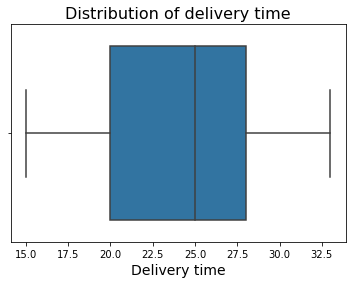

```python
bxp=sns.boxplot(data=df,x='delivery_time')
bxp.set_xlabel("Delivery time", fontsize=14)
bxp.axes.set_title("Distribution of delivery time", fontsize=16)
plt.show()
```

1. The minimum time a customer should expect the delivery of an order once confirmed by the delivery person for most online restaurants in New York is 15minutes.
2. The maximum time a customer should expect the delivery of an order once confirmed by the delivery person for most online restaurants in New York is around 33 minutes.
3. Most deliveries occured between 25 to 33 minutes after pick-up is been confirmed by the delivery person.
4. The data is skewed to the left
5. There are no outliers in this coloumn
6. 75% of the times deliveries were made by the delivery person, the time is took to deliver the food is below 28minutes

**Observations on Customer ID**

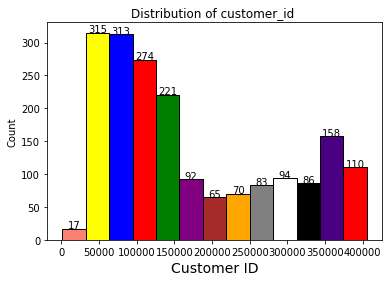

```python
ax = sns.histplot(df['customer_id'], color='#9d94ba', kde=False)
ax.set(title='Distribution of customer_id ')
ax.set_xlabel("Customer ID", fontsize=14)
# label each bar in histogram
for p in ax.patches:
 height = p.get_height() # get the height of each bar
 # adding text to each bar
 ax.text(x = p.get_x()+(p.get_width()/2), # x-coordinate position of data label, padded to be in the middle of the bar
 y = height+0.2, # y-coordinate position of data label, padded 0.2 above bar
 s = '{:.0f}'.format(height), # data label, formatted to ignore decimals
 ha = 'center') # sets horizontal alignment (ha) to center
 ax.patches[0].set_facecolor('salmon')
 ax.patches[1].set_facecolor('yellow')
 ax.patches[2].set_facecolor('blue')
 ax.patches[3].set_facecolor('red')
 ax.patches[4].set_facecolor('green')
 ax.patches[5].set_facecolor('purple')
 ax.patches[6].set_facecolor('brown')
 ax.patches[7].set_facecolor('orange')
 ax.patches[8].set_facecolor('gray')
 ax.patches[9].set_facecolor('white')
 ax.patches[10].set_facecolor('black')
 ax.patches[11].set_facecolor('indigo')
 ax.patches[12].set_facecolor('red')
```

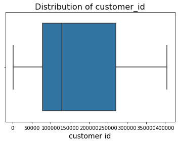

```python
bxp=sns.boxplot(data=df,x='customer_id')
bxp.set_xlabel("customer id", fontsize=14)
bxp.axes.set_title("Distribution of customer_id", fontsize=16)
plt.show()
```

- Majority of the customers who use the foodhub app for food ordering have customer id ranging from 40000 to 150000. *Therefore incase of any app promotion, customers with customer id ranging from 40000 to 150000 should be targeted to get the most out of the promotion.
- There are no outliers in the column
- The data is skewed to the right

**Observations on Order ID**

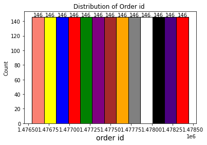

```python
ax = sns.histplot(df['order_id'], color='#9d94ba', kde=False)
ax.set(title='Distribution of Order id ')
ax.set_xlabel("order id", fontsize=14)
# label each bar in histogram
for p in ax.patches:
 height = p.get_height() # get the height of each bar
 # adding text to each bar
 ax.text(x = p.get_x()+(p.get_width()/2), # x-coordinate position of data label, padded to be in the middle of the bar
 y = height+0.2, # y-coordinate position of data label, padded 0.2 above bar
 s = '{:.0f}'.format(height), # data label, formatted to ignore decimals
 ha = 'center') # sets horizontal alignment (ha) to center
 ax.patches[0].set_facecolor('salmon')
 ax.patches[1].set_facecolor('yellow')
 ax.patches[2].set_facecolor('blue')
 ax.patches[3].set_facecolor('red')
 ax.patches[4].set_facecolor('green')
 ax.patches[5].set_facecolor('purple')
 ax.patches[6].set_facecolor('brown')
 ax.patches[7].set_facecolor('orange')
 ax.patches[8].set_facecolor('gray')
 ax.patches[9].set_facecolor('white')
 ax.patches[10].set_facecolor('black')
 ax.patches[11].set_facecolor('indigo')
 ax.patches[12].set_facecolor('red')
```

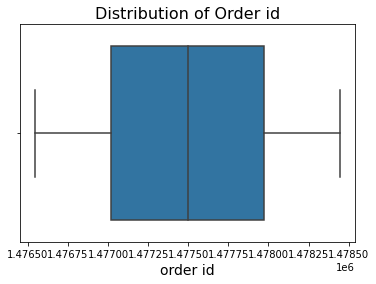

```python
bxp=sns.boxplot(data=df,x='order_id')
bxp.set_xlabel("order id", fontsize=14)
bxp.axes.set_title("Distribution of Order id", fontsize=16)
plt.show()
```

- The order_id has no reasonable information since they are just unique values for the identification of each order made.
- There are no outliers in the data

## Observations on categorical columns by checking the distribution for numerical columns.

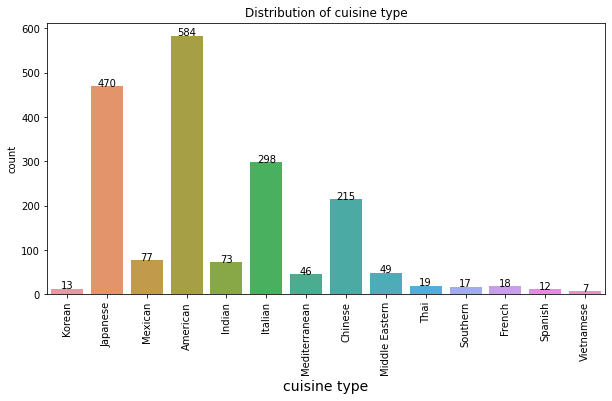

```python
plt.figure(figsize=(10,5))
ax = sns.countplot(df['cuisine_type'])
plt.xticks(rotation=90)
ax.set(title='Distribution of cuisine type')
ax.set_xlabel("cuisine type", fontsize=14)
# label each bar in the countplot
for p in ax.patches:
 height = p.get_height() # get the height of each bar
 # adding text to each bar
 ax.text(x = p.get_x()+(p.get_width()/2), # x-coordinate position of data label, padded to be in the middle of the bar
 y = height+0.2, # y-coordinate position of data label, padded 0.2 above bar
 s = '{:.0f}'.format(height), # data label, formatted to ignore decimals
 ha = 'center') # sets horizontal alignment (ha) to center
```

- Majority of the cusine types ordered by customers in New York through the food hub app are the Japanese, American, Italian and Chinese cuisine, with the American cuisine being the most ordered.
- Korean,Spanish and Vietnamese cuisine are among the least cuisines ordered by customers in New York.

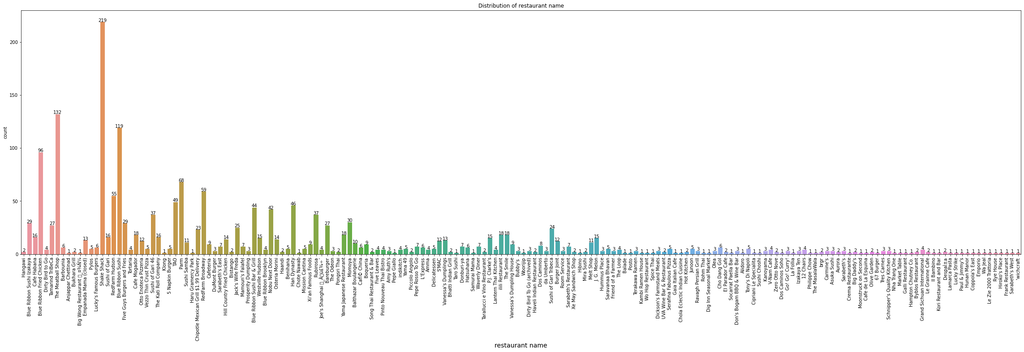

```python
plt.figure(figsize=(40,10))
ax = sns.countplot(df['restaurant_name'])
plt.xticks(rotation=90)
ax.set(title='Distribution of restaurant name')
ax.set_xlabel("restaurant name", fontsize=14)
# label each bar in the countplot
for p in ax.patches:
 height = p.get_height() # get the height of each bar
 # adding text to each bar
 ax.text(x = p.get_x()+(p.get_width()/2), # x-coordinate position of data label, padded to be in the middle of the bar
 y = height+0.2, # y-coordinate position of data label, padded 0.2 above bar
 s = '{:.0f}'.format(height), # data label, formatted to ignore decimals
 ha = 'center') # sets horizontal alignment (ha) to center
```

- The Shake shack, The meatball shop and Blue Ribbon Sushi are the three most patronized restaurants in the Foodhub app.
- Most of the restaurants have not recieved orders more than ten(10) times through the Foodhub app.

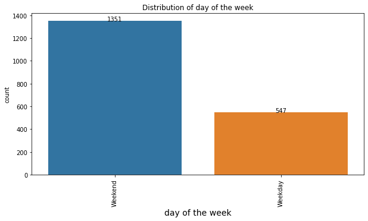

```python
plt.figure(figsize=(10,5))
ax = sns.countplot(df['day_of_the_week'])
plt.xticks(rotation=90)
ax.set(title='Distribution of day of the week')
ax.set_xlabel("day of the week", fontsize=14)
# label each bar in the countplot
for p in ax.patches:
 height = p.get_height() # get the height of each bar
 # adding text to each bar
 ax.text(x = p.get_x()+(p.get_width()/2), # x-coordinate position of data label, padded to be in the middle of the bar
 y = height+0.2, # y-coordinate position of data label, padded 0.2 above bar
 s = '{:.0f}'.format(height), # data label, formatted to ignore decimals
 ha = 'center') # sets horizontal alignment (ha) to center
```

- Well over 60% of the orders made by customers throught the foodhub app occurs on weekends.
- The Food aggregator company experiences less orders (less than 30% of total orders) on weekdays.

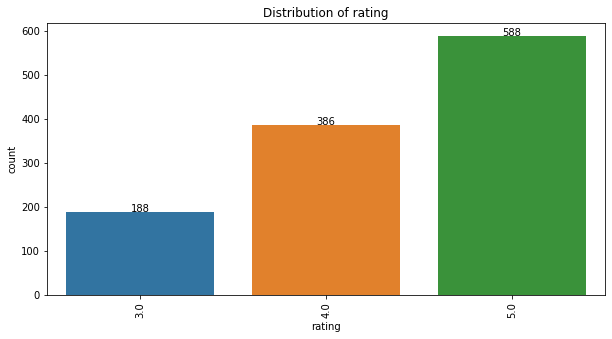

```python
plt.figure(figsize=(10,5))
ax = sns.countplot(df['rating'])
plt.xticks(rotation=90)
ax.set(title='Distribution of rating')
# label each bar in the countplot
for p in ax.patches:
 height = p.get_height() # get the height of each bar
 # adding text to each bar
 ax.text(x = p.get_x()+(p.get_width()/2), # x-coordinate position of data label, padded to be in the middle of the bar
 y = height+0.2, # y-coordinate position of data label, padded 0.2 above bar
 s = '{:.0f}'.format(height), # data label, formatted to ignore decimals
 ha = 'center') # sets horizontal alignment (ha) to center
```

Majority of the customers that gave there rating indicated they are satisfied

### **Question 7**: Which are the top 5 restaurants in terms of the number of orders received? [1 mark]

```python
# counting the number of occurence of each value in the restaurant series using value count method and setting sort attribute to True.
df['restaurant_name'].value_counts(sort=True)
```

```
Shake Shack                  219
The Meatball Shop            132
Blue Ribbon Sushi            119
Blue Ribbon Fried Chicken     96
Parm                          68
                            ...
Sushi Choshi                   1
Dos Caminos Soho               1
La Follia                      1
Philippe Chow                  1
'wichcraft                     1
Name: restaurant_name, Length: 178, dtype: int64
```

#### Observations:

- The top 5 restaurants in terms of orders recieved are

Shake Shack (219 orders), The Meatball Shop (132 orders), Blue Ribbon Sushi (119 orders), Blue Ribbon Fried Chicken (96 orders), and Parm (68 orders).

### **Question 8**: Which is the most popular cuisine on weekends? [1 mark]

```python
#groupby 'cusine_type' and count number of 'day_of_the_week' equal to 'Weekend'
df.groupby('cuisine_type')['day_of_the_week'].apply(lambda x: (x=='Weekend').sum()).reset_index(name='count')
```

|  | cuisine_type | count |
| --- | --- | --- |
| 0 | American | 415 |
| 1 | Chinese | 163 |
| 2 | French | 13 |
| 3 | Indian | 49 |
| 4 | Italian | 207 |
| 5 | Japanese | 335 |
| 6 | Korean | 11 |
| 7 | Mediterranean | 32 |
| 8 | Mexican | 53 |
| 9 | Middle Eastern | 32 |
| 10 | Southern | 11 |
| 11 | Spanish | 11 |
| 12 | Thai | 15 |
| 13 | Vietnamese | 4 |

#### Observations:

- The American cuisine is the most popular cuisine type on weekends.

### **Question 9**: What percentage of the orders cost more than 20 dollars? [2 marks]

```python
# Calculate the number of rows with 'cost_of_the_order' greater than 20 dollars, divide by the total number of rows and multiply by 100
df.loc[df['cost_of_the_order']>20].shape[0]/df.shape[0]*100
```

```
29.24130663856691
```

#### Observations:

*The percentage of orders that cost more than 20 dollars is 29.24%

### **Question 10**: What is the mean order delivery time? [1 mark]

```python
# Write the code here
Deliverymean = df[['delivery_time']].mean()
print(Deliverymean)
```

```
delivery_time    24.161749
dtype: float64
```

#### Observations:

- The mean order delivery time is 24.16 minutes, this is the average time it takes for a food to be delivered to the customer after pick up.

### **Question 11:** The company has decided to give 20% discount vouchers to the top 3 most frequent customers. Find the IDs of these customers and the number of orders they placed. [1 mark]

```python
# Counting the number of times a particular customer_id appeared in the column using value count method
df['customer_id'].value_counts()
```

```
52832     13
47440     10
83287      9
250494     8
259341     7
          ..
385426     1
254913     1
289597     1
74412      1
397537     1
Name: customer_id, Length: 1200, dtype: int64
```

#### Observations:

*The three top customers has the following customer ids and corresponding number of orders.

- Customer with the id 52832 ordered food 13 times
- Customer with the id 47440 ordered food 10 times and
- Customer with the id 83287 ordered food 9 times

### **Question 12**: Perform a multivariate analysis to explore relationships between the important variables in the dataset. (It is a good idea to explore relations between numerical variables as well as relations between numerical and categorical variables) [10 marks]

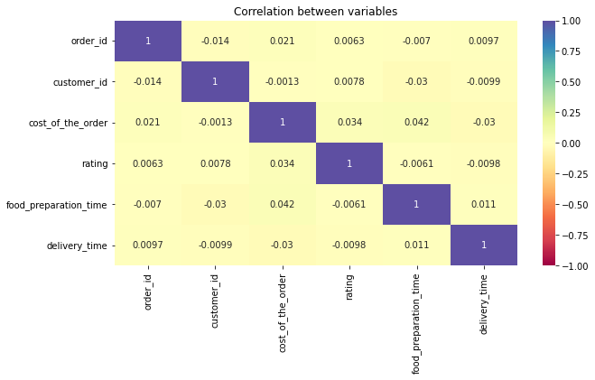

```python
plt.figure(figsize=(10,5))
ax=sns.heatmap(df.corr(),annot=True,cmap='Spectral',vmin=-1,vmax=1)
ax.set(title='Correlation between variables')
plt.show()
```

### Observations:

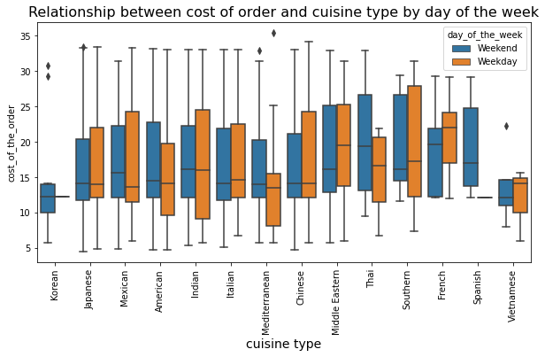

```python
plt.figure(figsize=(10,5))
bxp=sns.boxplot(data=df,x='cuisine_type', y='cost_of_the_order', hue="day_of_the_week")
bxp.set_xlabel("cuisine type", fontsize=14)
bxp.axes.set_title("Relationship between cost of order and cuisine type by day of the week", fontsize=16)
plt.xticks(rotation=90)
plt.show()
```

### Observations:

- 75% of Majority of the cuisine types bought by customers seems to cost more during weekdays than weekends.

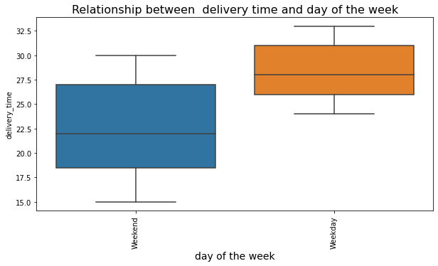

```python
plt.figure(figsize=(10,5))
bxp=sns.boxplot(data=df,x='day_of_the_week', y='delivery_time')
bxp.set_xlabel("day of the week", fontsize=14)
bxp.axes.set_title("Relationship between  delivery time and day of the week", fontsize=16)
plt.xticks(rotation=90)
plt.show()
```

### observation

*It takes longer time to deliver food orders on weekdays than on weekends.

- Customers should expect longer delivery time on weekdays than on weekends.

```python
df['Total_Time'] = df['food_preparation_time'] + df['delivery_time']
df.head()
```

|  | order_id | customer_id | restaurant_name | cuisine_type | cost_of_the_order | day_of_the_week | rating | food_preparation_time | delivery_time | Total_Time |
| --- | --- | --- | --- | --- | --- | --- | --- | --- | --- | --- |
| 0 | 1477147 | 337525 | Hangawi | Korean | 30.75 | Weekend | NaN | 25 | 20 | 45 |
| 1 | 1477685 | 358141 | Blue Ribbon Sushi Izakaya | Japanese | 12.08 | Weekend | NaN | 25 | 23 | 48 |
| 2 | 1477070 | 66393 | Cafe Habana | Mexican | 12.23 | Weekday | 5.0 | 23 | 28 | 51 |
| 3 | 1477334 | 106968 | Blue Ribbon Fried Chicken | American | 29.20 | Weekend | 3.0 | 25 | 15 | 40 |
| 4 | 1478249 | 76942 | Dirty Bird to Go | American | 11.59 | Weekday | 4.0 | 25 | 24 | 49 |

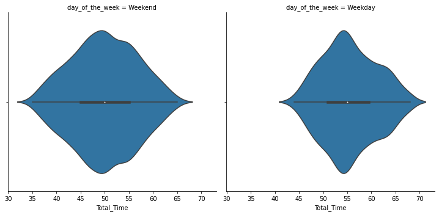

```python
#Lets check if the total time taken to  preparation and deliver the order varies with the day of the week
# Dispersion of total time spent on order by day of the week
sns.catplot(x='Total_Time',
            col='day_of_the_week',
            data=df,
            col_wrap=4,
            kind="violin")
plt.show()
```

### Observation:

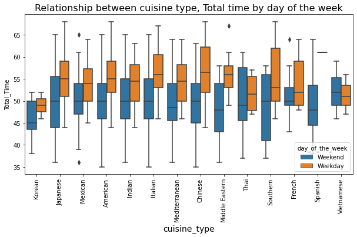

```python
plt.figure(figsize=(10,5))
bxp=sns.boxplot(data=df,x='cuisine_type', y='Total_Time', hue='day_of_the_week')
bxp.set_xlabel("cuisine_type", fontsize=14)
bxp.axes.set_title("Relationship between cuisine type, Total time by day of the week", fontsize=16)
plt.xticks(rotation=90)
plt.show()
```

### observation

Apart from Thai and Vietnamese cusines, the total time it takes to deliver cuisines is longer on weekdays than on weekends.

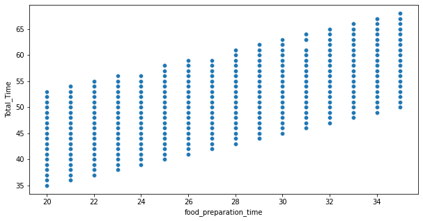

```python
plt.figure(figsize=(10,5))
sns.scatterplot(data=df,x='food_preparation_time',y='Total_Time')
plt.show()
```

### There is a linear relationship between the total time and food preparation time, as the time it takes to prepare a food order increases, the total time to get the food to a customer increases.

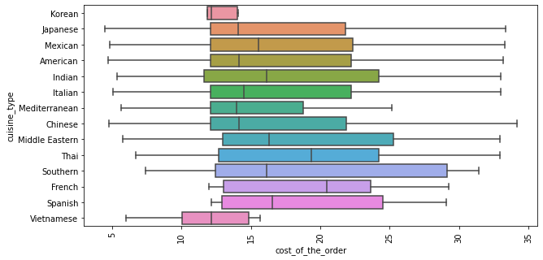

```python
plt.figure(figsize=(10,5))
sns.boxplot(data=df,x='cost_of_the_order',y='cuisine_type',showfliers=False) # turning off outliers
plt.xticks(rotation=90)
plt.show()
```

### observation

*Of the 75% of the orders made for different cuisines, Southern cuisine has the highest cost of order.

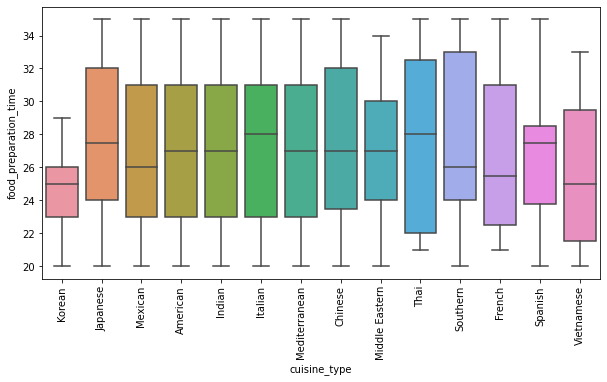

```python
plt.figure(figsize=(10,5))
sns.boxplot(data=df,x='cuisine_type',y='food_preparation_time',showfliers=False) # turning off outliers
plt.xticks(rotation=90)
plt.show()
```

### **observation**

Southern cuisine has the highest 75th percentile when it comes to food preparation time.

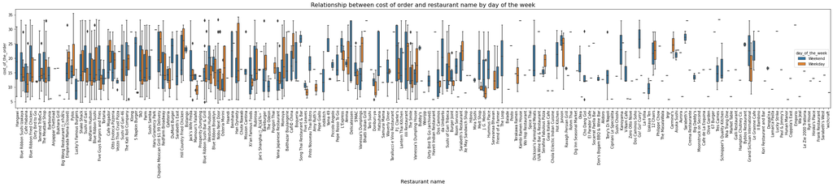

```python
plt.figure(figsize=(40,5))
bxp=sns.boxplot(data=df,x='restaurant_name', y='cost_of_the_order', hue="day_of_the_week")
bxp.set_xlabel("Restaurant name", fontsize=14)
bxp.axes.set_title("Relationship between cost of order and restaurant name by day of the week", fontsize=16)
plt.xticks(rotation=90)
plt.show()
```

### observation

- The cost of order in restaurants like pylos, han dynasty, momoya,Amma etc. increases more on weekdays.
- The cost of orders in restaurants like Five leaves, Donburi-ya, Grand Sichuan international etc reduces more on weekdays.

### **Question 13:** The company wants to provide a promotional offer in the advertisement of the restaurants. The condition to get the offer is that the restaurants must have a rating count of more than 50 and the average rating should be greater than 4. Find the restaurants fulfilling the criteria to get the promotional offer. [3 marks]

```python
# Write the code here

df_rated=df.dropna()
df_rated['rating']=df_rated['rating'].apply(int)
print(df_rated)

df_rating_count=df_rated.groupby(['restaurant_name'])['rating'].count().sort_values(ascending=False).reset_index()
print(df_rating_count)
rest_names=df_rating_count[df_rating_count['rating']>50]
print(rest_names)
df_mean_4=rest_names[rest_names['restaurant_name'].isin(['Shake Shack','The Meatball Shop','Blue Ribbon Sushi','Blue Ribbon Fried Chicken'])]
df_mean_4
df_mean_4.groupby('restaurant_name')['rating'].mean().sort_values(ascending=False).reset_index()
```

[output not shown]

[output cut: 44 more lines]

|  | restaurant_name | rating |
| --- | --- | --- |
| 0 | Shake Shack | 133.0 |
| 1 | The Meatball Shop | 84.0 |
| 2 | Blue Ribbon Sushi | 73.0 |
| 3 | Blue Ribbon Fried Chicken | 64.0 |

```python
df_mean_4.groupby('restaurant_name')['rating'].mean().sort_values(ascending=False).reset_index()
```

|  | restaurant_name | rating |
| --- | --- | --- |
| 0 | Shake Shack | 133.0 |
| 1 | The Meatball Shop | 84.0 |
| 2 | Blue Ribbon Sushi | 73.0 |
| 3 | Blue Ribbon Fried Chicken | 64.0 |

### **Question 14:** The company charges the restaurant 25% on the orders having cost greater than 20 dollars and 15% on the orders having cost greater than 5 dollars. Find the net revenue generated by the company across all orders. [3 marks]

```python
# Write the code here
df['revenue']=np.where(df['cost_of_the_order']>20,df['cost_of_the_order']*0.25,df['cost_of_the_order']*.15)
df
```

|  | order_id | customer_id | restaurant_name | cuisine_type | cost_of_the_order | day_of_the_week | rating | food_preparation_time | delivery_time | Total_Time | revenue |
| --- | --- | --- | --- | --- | --- | --- | --- | --- | --- | --- | --- |
| 0 | 1477147 | 337525 | Hangawi | Korean | 30.75 | Weekend | NaN | 25 | 20 | 45 | 7.6875 |
| 1 | 1477685 | 358141 | Blue Ribbon Sushi Izakaya | Japanese | 12.08 | Weekend | NaN | 25 | 23 | 48 | 1.8120 |
| 2 | 1477070 | 66393 | Cafe Habana | Mexican | 12.23 | Weekday | 5.0 | 23 | 28 | 51 | 1.8345 |
| 3 | 1477334 | 106968 | Blue Ribbon Fried Chicken | American | 29.20 | Weekend | 3.0 | 25 | 15 | 40 | 7.3000 |
| 4 | 1478249 | 76942 | Dirty Bird to Go | American | 11.59 | Weekday | 4.0 | 25 | 24 | 49 | 1.7385 |
| ... | ... | ... | ... | ... | ... | ... | ... | ... | ... | ... | ... |
| 1893 | 1476701 | 292602 | Chipotle Mexican Grill $1.99 Delivery | Mexican | 22.31 | Weekend | 5.0 | 31 | 17 | 48 | 5.5775 |
| 1894 | 1477421 | 397537 | The Smile | American | 12.18 | Weekend | 5.0 | 31 | 19 | 50 | 1.8270 |
| 1895 | 1477819 | 35309 | Blue Ribbon Sushi | Japanese | 25.22 | Weekday | NaN | 31 | 24 | 55 | 6.3050 |
| 1896 | 1477513 | 64151 | Jack's Wife Freda | Mediterranean | 12.18 | Weekday | 5.0 | 23 | 31 | 54 | 1.8270 |
| 1897 | 1478056 | 120353 | Blue Ribbon Sushi | Japanese | 19.45 | Weekend | NaN | 28 | 24 | 52 | 2.9175 |

1898 rows × 11 columns

```python
df['revenue'].sum()
```

```
6172.714
```

### **Question 15:** The company wants to analyze the total time required to deliver the food. What percentage of orders take more than 60 minutes to get delivered from the time the order is placed? (The food has to be prepared and then delivered.) [2 marks]

```python
# Write the code here
df.loc[df['Total_Time']>60].shape[0]/df.shape[0]*100
```

```
10.537407797681771
```

#### Observations:

About 10.53% of the orders takes more than 60minutes to be delivered

### **Question 16:** The company wants to analyze the delivery time of the orders on weekdays and weekends. How does the mean delivery time vary during weekdays and weekends? [2 marks]

```python
# Write the code here
# df.groupby(['day_of_the_week])['delivery_time']).mean()
df.groupby('day_of_the_week')['delivery_time'].mean()
```

```
day_of_the_week
Weekday    28.340037
Weekend    22.470022
Name: delivery_time, dtype: float64
```

#### Observations:

*The mean delivery time of the weekday is longer then the mean delivery time on weekends. Therefore most food orders made on weekdays takes longer time to be delivered to customers than on weekends.

### Conclusion and Recommendations

### **Question 17:** What are your conclusions from the analysis? What recommendations would you like to share to help improve the business? (You can use cuisine type and feedback ratings to drive your business recommendations.) [6 marks]

### Conclusions:

- Majority of the cusine types ordered by customers in New York through the food hub app are the Japanese, American, Italian and Chinese cuisine, with the American cuisine being the most ordered.
- Most active customers who use the foodhub app more freqently for food ordering have customer id ranging from 40000 to 150000.
- The Shake shack, The meatball shop and Blue Ribbon Sushi are the three most patronized restaurants in the Foodhub app.
- The American cuisine is the most popular cuisine type on weekends.
- The percentage of orders that cost more than 20 dollars is 29.24%
- 75% of Majority of the cuisine types bought by customers seems to cost more during weekdays than weekends.
- Customers should expect longer delivery time on weekdays than on weekends.
- Of the 75% of the orders made for different cuisines, Southern cuisine has the highest cost of order.
- The cost of order in restaurants like pylos, han dynasty, momoya,Amma etc. increases more on weekdays.
- Shake Shack, The Meatball Shop and Blue Ribbon Sushi are the top three restaurants with the highest number of rating.